# Fedspeak Documentation

Darren Chang

2020-06-20

## Introduction

[Beige Book](https://www.federalreserve.gov/monetarypolicy/beige-book-default.htm)

## Text Mining

Text mining was completed in `Python 3.7` using `BeautifulSoup`. Setup by importing `Pandas`, `BeauitfulSoup`, and `Requests`.

```python
## ---- setup
import pandas as pd
import numpy as np

import os #setwd
import time #timing

# scraping
from bs4 import BeautifulSoup
from contextlib import closing
import requests # website requests
from requests.exceptions import RequestException
from requests import get
```

We scrape the [Minneapolis Fed’s Beige Book Archive](https://www.minneapolisfed.org/region-and-community/regional-economic-indicators/beige-book-archive), which hosts `html` files for each Beige Book back to 1970. The links to each website to be scraped is in the `links.csv` file in this repo. Import it as a dataframe.

```python
links = pd.read_csv('C:/Users/darre/Documents/_econ/fedspeak/text mining/links.csv')
links.head(20)
```

```
##     year  month  ...      report      date
## 0   1970      5  ...  1970-05-at  5/1/1970
## 1   1970      5  ...  1970-05-bo  5/1/1970
## 2   1970      5  ...  1970-05-ch  5/1/1970
## 3   1970      5  ...  1970-05-cl  5/1/1970
## 4   1970      5  ...  1970-05-da  5/1/1970
## 5   1970      5  ...  1970-05-kc  5/1/1970
## 6   1970      5  ...  1970-05-mi  5/1/1970
## 7   1970      5  ...  1970-05-ny  5/1/1970
## 8   1970      5  ...  1970-05-ph  5/1/1970
## 9   1970      5  ...  1970-05-ri  5/1/1970
## 10  1970      5  ...  1970-05-sf  5/1/1970
## 11  1970      5  ...  1970-05-sl  5/1/1970
## 12  1970      5  ...  1970-05-su  5/1/1970
## 13  1970      6  ...  1970-06-at  6/1/1970
## 14  1970      6  ...  1970-06-bo  6/1/1970
## 15  1970      6  ...  1970-06-ch  6/1/1970
## 16  1970      6  ...  1970-06-cl  6/1/1970
## 17  1970      6  ...  1970-06-da  6/1/1970
## 18  1970      6  ...  1970-06-kc  6/1/1970
## 19  1970      6  ...  1970-06-mi  6/1/1970
##
## [20 rows x 6 columns]
```

```python
links.tail(20)
```

```
##       year  month  ...      report      date
## 5674  2020      3  ...  2020-03-mi  3/1/2020
## 5675  2020      3  ...  2020-03-ny  3/1/2020
## 5676  2020      3  ...  2020-03-ph  3/1/2020
## 5677  2020      3  ...  2020-03-ri  3/1/2020
## 5678  2020      3  ...  2020-03-sf  3/1/2020
## 5679  2020      3  ...  2020-03-sl  3/1/2020
## 5680  2020      3  ...  2020-03-su  3/1/2020
## 5681  2020      4  ...  2020-04-at  4/1/2020
## 5682  2020      4  ...  2020-04-bo  4/1/2020
## 5683  2020      4  ...  2020-04-ch  4/1/2020
## 5684  2020      4  ...  2020-04-cl  4/1/2020
## 5685  2020      4  ...  2020-04-da  4/1/2020
## 5686  2020      4  ...  2020-04-kc  4/1/2020
## 5687  2020      4  ...  2020-04-mi  4/1/2020
## 5688  2020      4  ...  2020-04-ny  4/1/2020
## 5689  2020      4  ...  2020-04-ph  4/1/2020
## 5690  2020      4  ...  2020-04-ri  4/1/2020
## 5691  2020      4  ...  2020-04-sf  4/1/2020
## 5692  2020      4  ...  2020-04-sl  4/1/2020
## 5693  2020      4  ...  2020-04-su  4/1/2020
##
## [20 rows x 6 columns]
```

Next, we define our scraping functions that iterate through the links, opens the url, and returns all of the text with the `<p>` tag. Much of the code for this portion was taken from Real Python’s [guide to web scraping](https://realpython.com/python-web-scraping-practical-introduction/).

```python
## ---- scraping
# functions for getting URLs, with error logging
def simple_get(url):
    """
    Attempts to get the content at `url` by making an HTTP GET request.
    If the content-type of response is some kind of HTML/XML, return the
    text content, otherwise return None.
    """
    try:
        with closing(get(url, stream = True)) as resp:
            if is_good_response(resp):
                soup = BeautifulSoup(resp.content, 'html.parser')
                results = soup.find_all('p')
                return results
            else:
                return None
    except RequestException as e:
        log_error('Error during requests to {0} : {1}'.format(url, str(e)))
        return None


def is_good_response(resp):
    """
    Returns True if the response seems to be HTML, False otherwise.
    """
    content_type = resp.headers['Content-Type'].lower()
    return (resp.status_code == 200
            and content_type is not None
            and content_type.find('html') > -1)

def log_error(e):
    """
    log errors
    """
    print(e)
```

We define another function to do the actual work of scraping. This returns a dataframe with the metadata about the website we’re scraping (date, year, bank, url) merged with lists of lists of the actual text in each page.

```python
# scraping a set of links
def scrape(links, #dataframe of urls and other info
):
    """
    function for scraping set of links to dataframe.
    returns data frame of raw text in lists of lists
    """
    links_use = links['url'].values.tolist() # extract urls as list
    fed_text_raw = pd.DataFrame() #empty df

    for url in links_use:
        text = simple_get(url)
        df = pd.DataFrame({'url': url, 'text': [text]})
        fed_text_raw = fed_text_raw.append(df, ignore_index = True)
    fed_text_raw = pd.DataFrame(fed_text_raw)
    fed_text_raw.columns = fed_text_raw.columns.str.strip() #strip column names

    return fed_text_raw
```

Finally, we scrape our links. The returned file was over 1GB when saved as a csv file and the process usually takes about 2.5 hours. I would recommend exporting it (to csv or whatever file storage format you prefer) to avoid scraping multiple times.

```python
fed_text_raw = scrape(links)
```

## Cleaning Data

We come to the unenviable task of cleaning the data, which represents a few million words from 50 years of Beige Book Reports. First, we strip the dataset of html tags and numbers. When using `BeautifulSoup`, this is often done with the `get_text()` command; however, we use `find_all` with the html paragraph tag to scrape our data, so `get_text` does not work for this case.

### Preprocessing

The following function uses regex to replace characters, html tags, and other wacky spacing issues.

```python
## ---- cleaning

def preprocess(df,
 text_field, # field that has text
 new_text_field_name # name of field that has normalized text
 ):
    """
    normalizes dataframes by converting it to lowercase and
    removing characters that do not contribute to natural text meaning
    """
    df[new_text_field_name] = (df[text_field]
        .apply(lambda elem: re.sub(r"(@[A-Za-z0-9]+)|([^0-9A-Za-z \t])|(\w+:\/\/\S+)|^rt|http.+?",
            "", str(elem)))
        .apply(lambda elem: re.sub("<.*?>","", str(elem))) # strips out tags
        .apply(lambda elem: re.sub(r"\d+", "", str(elem)))
        )

    return df
```

### Tokenization

We want to convert our bag of words for each report into the tidy text format, which Julia Silge and David Robinson define in Chapter 1 of [*Text Mining in R*](https://www.tidytextmining.com/tidytext.html) as:

> We thus define the tidy text format as being **a table with one-token-per-row**. A token is a meaningful unit of text, such as a word, that we are interested in using for analysis, and tokenization is the process of splitting text into tokens. This one-token-per-row structure is in contrast to the ways text is often stored in current analyses, perhaps as strings or in a document-term matrix. For tidy text mining, the **token** that is stored in each row is most often a single word, but can also be an n-gram, sentence, or paragraph. In the tidytext package, we provide functionality to tokenize by commonly used units of text like these and convert to a one-term-per-row format.

You may ask: why would you want to use a `tidy` format if we’re using Python? This is a good question, but here were some of my reasons:

1. `NLTK` is set up to use ML techniques for sentiment analysis
   - The basic sentiment analysis technique we are using involves matching words in our data with a predefined dictionary.
   - The `tidytext` package preloads the Loughran-McDonald dictionary, which is useful for analysis of finance (and economics-related) literature. More on this later, and the usage of different lexicon.
2. CSV files struggle with lengthy lists of lists.
   - Sometimes there are display errors.
   - Sometimes there are errors where the list is too many characters.
   - The processing speed can be quite slow.
3. I’m personally more familiar with visualization with `ggplot2`.

Here, we define a function for word tokenization, which borrows heavily from [Michelle Fullwood’s](https://github.com/michelleful) [project](https://github.com/michelleful/TidyTextMining-Python) to convert *Text Mining in R* to Python. I have modified the function to merge the tokens with the original list of links based on the date of the report.

```python
# word tokenization
def unnest(df, # line-based dataframe
                  column_to_tokenize, # name of the column with the text
                  new_token_column_name, # what you want the column of words to be called
                  tokenizer_function, # what tokenizer to use = (nltk.word_tokenize)
                  original_list): # original list of data
    """
    unnests words from html and returns dataframe in long format merged with original list.
    word tokenization in tidy text format.
    """

    return (df[column_to_tokenize]
                .apply(str)
                .apply(tokenizer_function)
                .apply(pd.Series)
                .stack()
                .reset_index(level=0)
                .set_index('level_0')
                .rename(columns={0: new_token_column_name})
                .join(df.drop(column_to_tokenize, 1), how='left')
                .reset_index(drop=True)
                .merge(original_list, how = 'outer', on = 'url')
              )
```

To complete the preprocessing and tokenization process, we apply the functions to our raw data, convert it to lowercase (which is easier for future processes) and save it as a `csv` file to call it for future use.

```python
fed_text_raw = preprocess(fed_text_raw, 'text', 'text')
fed_text_all = unnest(fed_text_raw, 'text', 'word', nltk.word_tokenize, links)
fed_text_all['word'] = fed_text_all['word'].str.lower() # convert to lowercase
fed_text_all.to_csv('fed_text_all.csv', index = False) # save as csv
```

#### Dask

If you find that `pandas` is too slow for these applications or for your data, you may want to look into `dask`, which uses multi-core processing in addition to other goodies to speed things up for large datasets. Shikhar Chauhan has a blog post about using dask for text pre-processing at [MindOrks](https://medium.com/mindorks/speeding-up-text-pre-processing-using-dask-45cc3ede1366).

### Stemming

Here’s a stemming function that would work on a `tidy` formatted dataframe of words. I didn’t end up using stemming (and instead used lemmatization) because I found stemming removed too much — what should have been words simply became nonsensical stems. [DataCamp](http://datacamp.co/) has a tutorial for both stemming and lemmatization and compares the two methods [here](https://www.datacamp.com/community/tutorials/stemming-lemmatization-python).

```python
snowball = SnowballStemmer(language = 'english')
def stemming(df,
             column_to_stem,
             stem_function, # what stemming function to use = snowball
             ):
     """
     returns stem of words in a dataframe
     """

     return (df[column_to_stem]
                 .apply(stem_function)
                 )

 stemming(fed_text_all, 'word', snowball.stem)
```

### Lemmatization

Instead of stemming, I lemmatized the text by comparing the verbs in the data to the WordNet corpus in `NLTK`. This reduces a word like “swimming” to “swim,” which dictionaries pick up better for sentiment analysis.

```python
wordnet_lemmatizer = WordNetLemmatizer()
def lemmatize(df,
            column_to_lemmatize,
            lemmatize_func, # lemmatizing function to use = wordnet
            ):
    """
    returns root words by matching with the lemmatizing function
    """

    return (df[column_to_lemmatize]
                .apply(lambda word: lemmatize_func.lemmatize(word, pos = "v")) # part of speech is set to verb
                )

fed_text_all['word'] = lemmatize(fed_text_all, 'word', wordnet_lemmatizer) # lemmatize
```

### Stopwords

To finish the cleaning process, I remove stop words from the data, which keeps roughly 60 percent of the raw data (the csv file becomes 600 MB). Stop words are words that do not contribute to the meaning of a selection. The list of `NLTK` stopwords, which is used in this code is available in [this resource](https://www.nltk.org/book/ch02.html) for the package.

I add to the stop words list:

1. Left over html tags, such as “pp.”
2. A custom list of stop words for the economic context.
   - Words such as “maturity” or “work” may be coded as positive in natural language but means something different in economics.
   - Similarly, words such as “gross” (domestic product) or “crude” (oil) may be coded as negative, but do not have such a negative conntation.
   - Len Kiefer’s [blog post](http://lenkiefer.com/2018/07/29/beige-ian-statistics/) about this was helpful, and the list is taken from his post.

```python
# make custom stop words list
stop_words = stopwords.words("english")
stop_words_html = ['ppwe', 'uspp', 'pwe', 'usp', 'pp', 'usbrp'] # leftover stopwords from converting html to text
# with 'p' tags
stop_words_econ = ['debt', 'gross', 'crude', 'well', 'maturity', 'work', 'marginally', 'leverage'] # stop words for economic usage

stop_words.extend(stop_words_html)
stop_words.extend(stop_words_econ)

# delete stopwords
def remove_stops(df,
                column_to_process,
                stop_words_list, # list of stop words = stop_words
                index_reset = True # whether you want to reset index or not
                ):
    """
    function remove stopwords if data is a pandas dataframe and in tidy format e.g. long.
    different from typical pandas format which is lists of words in wide format.
    """
    if index_reset == True:
        return (df[~df[column_to_process].isin(stop_words_list)]
                .reset_index(drop = True)) # this line resets index
    else:
        return df[~df[column_to_process].isin(stop_words_list)]

# remove_stops(fed_text_test, 'word', stop_words) # test code
fed_text_all = remove_stops(fed_text_all, 'word', stop_words)
```

We save the cleaned data as a csv to read it later for sentiment analysis.

```python
fed_text_all.to_csv('fed_text_all.csv', index = False) # save as csv
```

But before that, some word frequency summary statistics:

```python
# summary statistics
fed_text_all = pd.read_csv('C:/Users/darre/Documents/_econ/fedspeak/text mining/fed_text_all.csv') # read csv
fed_text_all['word'].value_counts().head(20)
```

```
## report      131710
## district     89069
## increase     82694
## sales        79021
## price        76307
## continue     60095
## demand       56050
## contact      52839
## remain       50238
## activity     49760
## year         46716
## percent      46371
## new          45514
## p            43508
## loan         43425
## expect       37645
## level        36247
## market       36023
## strong       34933
## bank         34497
## Name: word, dtype: int64
```

## Sentiment Analysis

### in R

The `tidytext` package has a convenient `get_sentiments()` function, which essentially uses a merge method to match a pre-defined dictionary to the data in tidy format. We use python to emulate this method in a following section.

Let’s first load some packages and set up our working environment. I use the `vroom` package that is part of the `tidyverse` to load in the file with all of the words. It is significantly faster and easier to use than any `read_csv` function that I’ve used before.

```r
library(tidyverse)
library(tidytext)
library(vroom)
library(ggthemes)
library(zoo)

setwd("C:\\Users\\darre\\Documents\\_econ\\fedspeak\\sentiment analysis")
fed_text_all <- vroom('C:\\Users\\darre\\Documents\\_econ\\fedspeak\\text mining\\fed_text_all.csv') # read csv
```

```
## Rows: 6,614,408
## Columns: 7
## chr [5]: word, url, bank, report, date
## dbl [2]: year, month
##
## Pass a specification to the `col_types` argument to quiet this message
```

```r
recessions.df <- read.table(textConnection(
    "Peak, Trough
    1948-11-01, 1949-10-01
    1953-07-01, 1954-05-01
    1957-08-01, 1958-04-01
    1960-04-01, 1961-02-01
    1969-12-01, 1970-11-01
    1973-11-01, 1975-03-01
    1980-01-01, 1980-07-01
    1981-07-01, 1982-11-01
    1990-07-01, 1991-03-01
    2001-03-01, 2001-11-01
    2007-12-01, 2009-06-01"),
    sep=',',
    colClasses = c('Date', 'Date'),
    header = TRUE)
```

#### Polarity

We find the polarity from our data by report with the `inner_join` method in *Text Mining in R*:

```r
fed_sentiment <-
    fed_text_all %>%
    inner_join(get_sentiments("loughran")) %>% # or bing
    # inner_join(get_sentiments("bing")) %>%
    count(date, sentiment) %>%
    pivot_wider(names_from = sentiment,
                values_from = n,
                values_fill = 0) %>%
    mutate(sentiment = (positive - negative)/(positive + negative)) %>%
    mutate(date = as.Date(date, format = "%m/%d/%Y")) %>%
    filter(sentiment != 1) %>%
    filter(date != "2015-07-01") %>%
    mutate(sent_ma = rollmean(sentiment, k = 3, fill = NA)) %>%
    select(date, sentiment, sent_ma) %>%
    pivot_longer(-date,
            names_to = 'transformation',
            values_to = 'value') %>%
    mutate(transformation = as_factor(transformation))
```

Here is the plot:

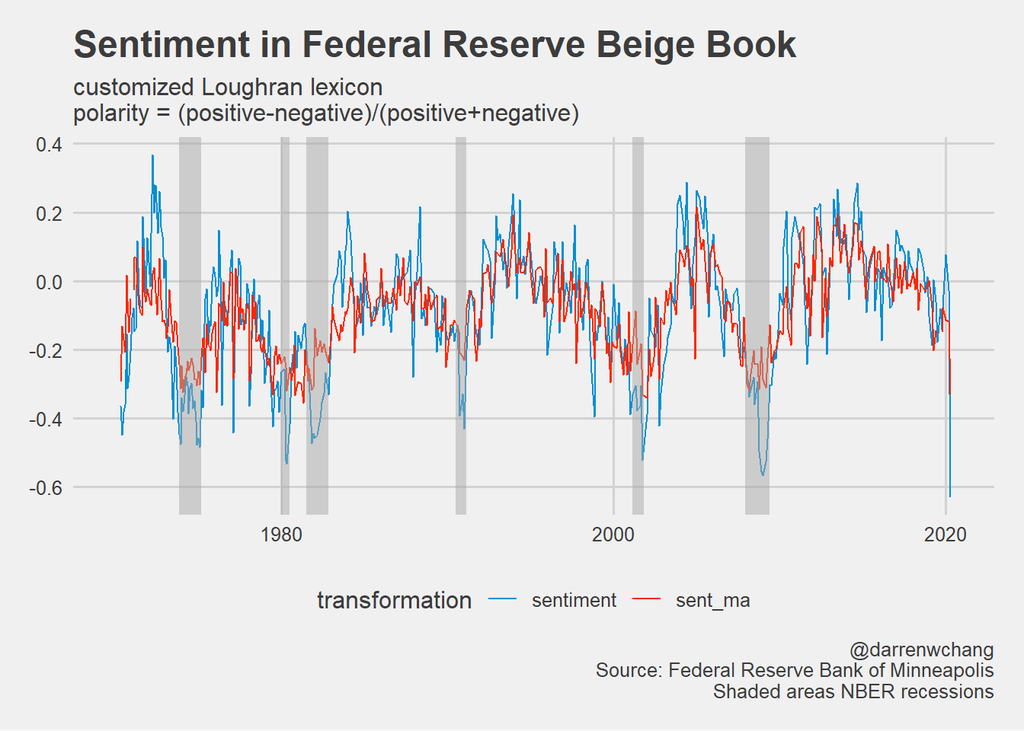

```r
ggplot(fed_sentiment,
    aes(x = date,
        y = value,
        color = transformation)) +
    geom_line(aes()) +
    scale_color_fivethirtyeight() +
    theme_fivethirtyeight() +
    scale_x_date(
        #breaks = "5 years",
    limits = as.Date(c("1970-01-01","2020-06-01")),
    date_labels = "%Y") +
    labs(x = "Beige Book Report (~8/year)",
        y = "polarity",
        title = "Sentiment in Federal Reserve Beige Book",
        subtitle = "customized Loughran lexicon\npolarity = (positive-negative)/(positive+negative)",
        caption = "@darrenwchang\nSource: Federal Reserve Bank of Minneapolis\nShaded areas NBER recessions") +
    geom_rect(data=recessions.df,
                    inherit.aes = F,
                aes(xmin = Peak,
                    xmax = Trough,
                    ymin = -Inf,
                    ymax = +Inf),
                    fill='darkgray',
                    alpha=0.5)
```

Even this raw data, without any adjustments, appears to track recessions well. It’s not clear if this is a leading or lagging indicator, or neither. Note that the moving averages may lose some of the power in terms of matching recessions.

We can also plot the sentiment by bank using the `facet_wrap` object in `ggplot2`. This yields interesting results: the authors at the different Federal Reserve banks have different scales, thus changing the composition of the data when each bank (and the national summary) is given equal weight.

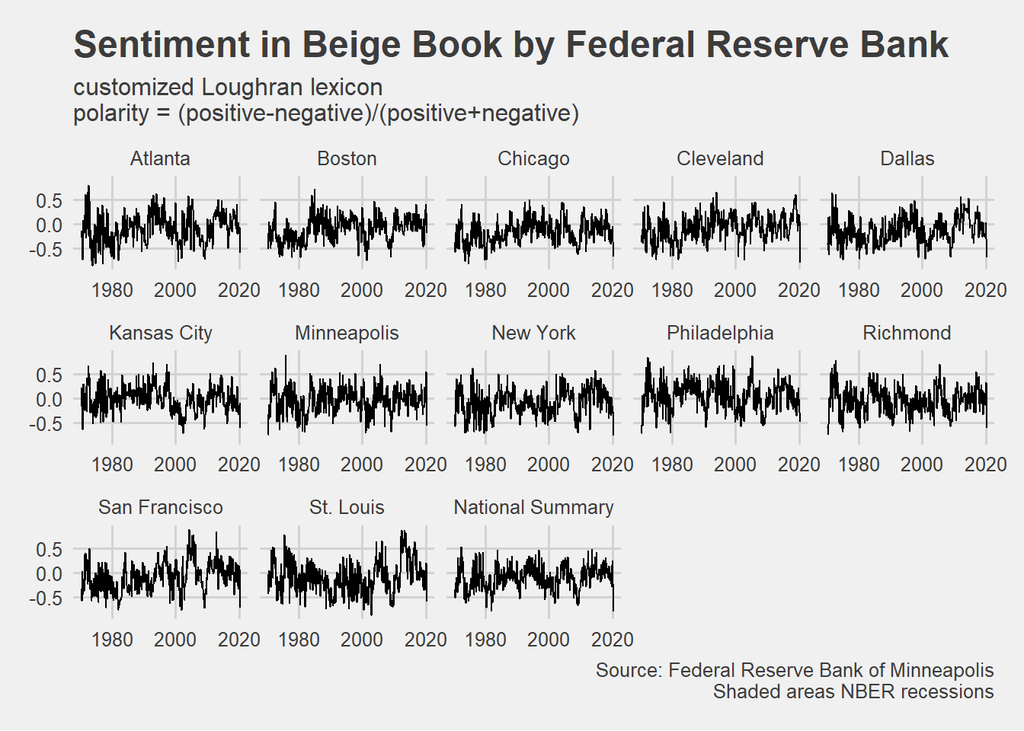